# **Project 2**, APS1070 Fall 2023

## **Part 3: Multiple feature model with one Gaussian distribution: [1 Marks]**

This part is similar to Part 2, but we will pick multiple features and **visually** set the number of components.

a. 2D plot:

1. Pick two features (say, f1 and f2).
2. Scatter plot (plt.scatter) those features on a figure (f1 on the x-axis and f2 on the y-axis).
3. Color the data points based on their class (not-fraud blue and fraud red).
4. Based on your plots, decide how many Gaussian components (`n_components`) you need to fit the data (focus on valid transactions). Explain. **[0.25]**
5. Fit your Gaussian model on all the data points.
6. Compute AUC on both training and validation sets
7. Pick 3 new pairs of features and repeat steps 2 to 6. **[0.25]**
8. For each pair, find a threshold to maximize your validation set F1 Score.**[0.25]**
9. For each pair, plot a figure similar to step 3 and put a circle around outliers based on your threshold (use the code of the similar figure in the tutorial) **[0.25]**

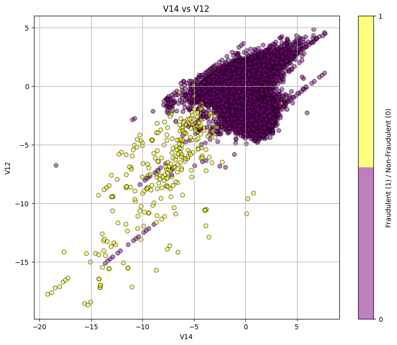

```python
### YOUR CODE HERE ###
import matplotlib.pyplot as plt
from matplotlib.colors import ListedColormap

colors = ['purple', 'yellow']
cmap = ListedColormap(colors)

# Pick the two features from the 3 top
feature_x = 'V14'
feature_y = 'V12'

# Create the scatter plot
plt.figure(figsize=(10, 8))
scatter = plt.scatter(X_train[feature_x], X_train[feature_y], c=y_train, cmap=cmap, alpha=0.5, edgecolors='k')
plt.xlabel(feature_x)
plt.ylabel(feature_y)
plt.title(f'{feature_x} vs {feature_y}')
# Create a binary colorbar
cbar = plt.colorbar(scatter, ticks=[0, 1])
cbar.set_label('Fraudulent (1) / Non-Fraudulent (0)')
plt.grid(True)
plt.show()
```

```python
"""
Based on the plot above I'm going to use 2 components. This is because there
visually, there seems to be 2 distinct distributions, with a little bit of either
class leaking over into the others distribution. I think making more than
2 distributions would be overfitting.
"""
# Extract the two features from dataset
X_two_features = X_train[['V14', 'V12']]

# Fit a GMM with 2 components
gmm = GaussianMixture(n_components=2)
gmm.fit(X_two_features)
# Compute the negative log-likelihood for the training set
train_scores = -gmm.score_samples(X_train[['V14', 'V12']])
train_auc = roc_auc_score(y_train, train_scores)

# Compute the negative log-likelihood for the validation set
val_scores = -gmm.score_samples(X_val[['V14', 'V12']])
val_auc = roc_auc_score(y_val, val_scores)
print("For V14 and V12")
print(f"Training AUC: {train_auc:.4f}")
print(f"Validation AUC: {val_auc:.4f}")
```

```
For V14 and V12
Training AUC: 0.9571
Validation AUC: 0.9801
```

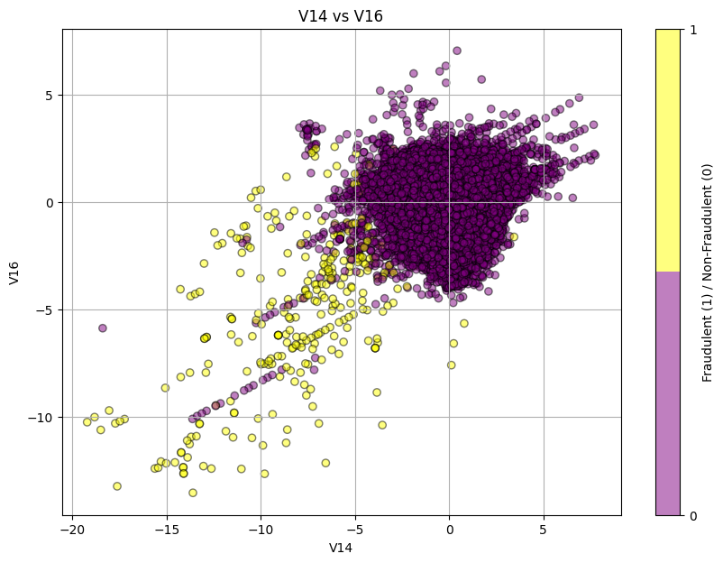

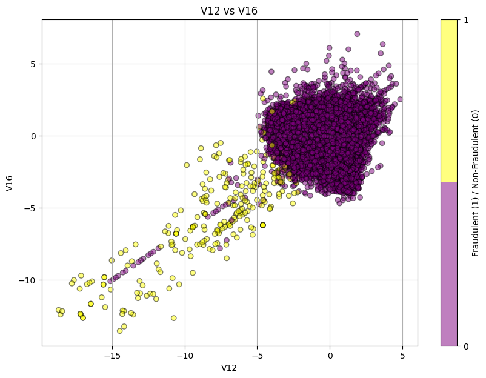

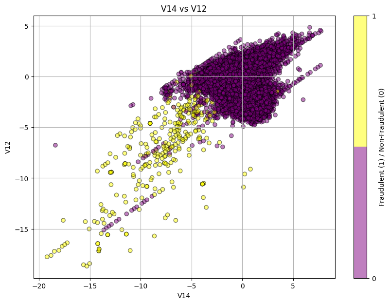

[output not shown]

```python
#Now for 3 new pairs:
# import seaborn as sns

feature_pairs = [X_train[['V14', 'V16']], X_train[['V12', 'V16']], X_train[['V14', 'V12']]]
pair_names = [('V14', 'V16'), ('V12', 'V16'), ('V14', 'V12')]

# Do Plotting
for idx, features in enumerate(feature_pairs):
    colors = ['purple', 'yellow']
    cmap = ListedColormap(colors)

    plt.figure(figsize=(10,7))
    scatter = plt.scatter(features[pair_names[idx][0]], features[pair_names[idx][1]], c=y_train, cmap=cmap, alpha=0.5, edgecolors='k')

    plt.xlabel(pair_names[idx][0])
    plt.ylabel(pair_names[idx][1])

    cbar = plt.colorbar(scatter, ticks=[0, 1])
    cbar.set_label('Fraudulent (1) / Non-Fraudulent (0)')

    plt.title(f'{pair_names[idx][0]} vs {pair_names[idx][1]}')
    plt.grid(True)
    plt.show()

feature_pairs = [('V14', 'V16'), ('V12', 'V16'), ('V14', 'V12')]
results = []

for pair in feature_pairs:
    # Extract data for the current feature pair
    X_train_pair = X_train[list(pair)]
    X_val_pair = X_val[list(pair)]

    # Fit a Gaussian Mixture Model with 2 components to the training data
    gmm = GaussianMixture(n_components=2, random_state=42)
    gmm.fit(X_train_pair)

    # Calculate the scores for the training and validation data
    train_scores = -gmm.score_samples(X_train_pair)
    val_scores = -gmm.score_samples(X_val_pair)

    # Compute the AUC for both training and validation sets
    train_auc = roc_auc_score(y_train, train_scores)
    val_auc = roc_auc_score(y_val, val_scores)

    # F1 Score calculation
    best_f1 = 0
    best_threshold = 0
    for threshold in np.linspace(val_scores.min(), val_scores.max(), 100):
        y_pred = (val_scores > threshold).astype(int)
        current_f1 = f1_score(y_val, y_pred)
        if current_f1 > best_f1:
            best_f1 = current_f1
            best_threshold = threshold

    results.append({
        'Feature Pair': pair,
        'Train AUC': train_auc,
        'Validation AUC': val_auc,
        'Best F1 Score': best_f1,
        'Best Threshold': best_threshold
    })

# Convert results to a DataFrame for better visualization
results_df = pd.DataFrame(results)

results_df
```

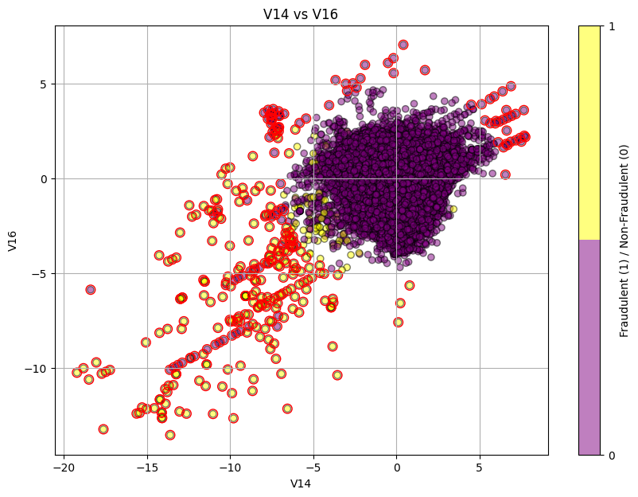

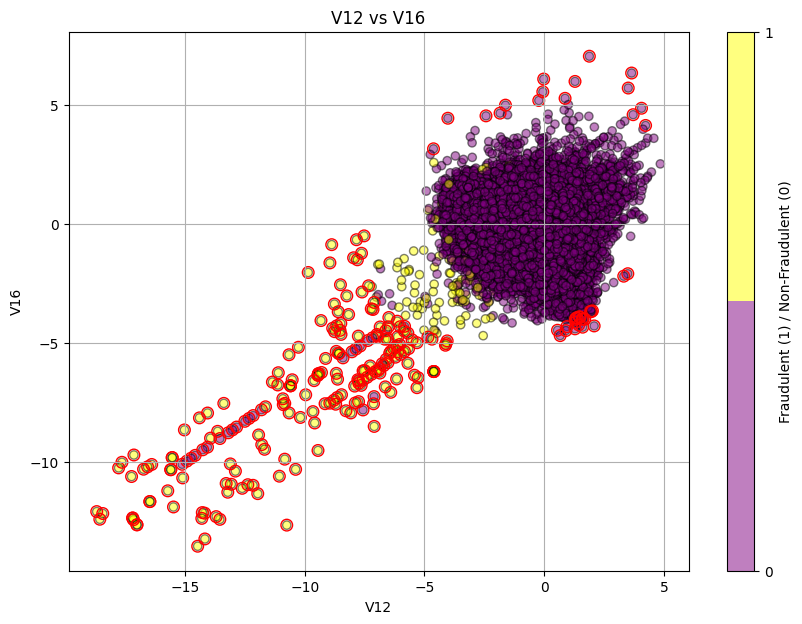

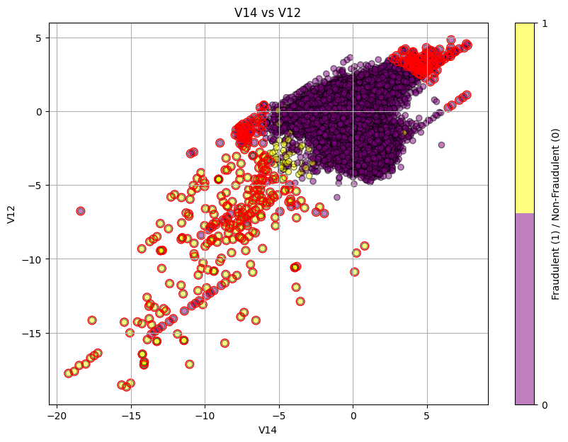

```python
# Plot Outliers:
pair_names = [('V14', 'V16'), ('V12', 'V16'), ('V14', 'V12')]

colors = ['purple', 'yellow']
cmap = ListedColormap(colors)

for idx, pair in enumerate(pair_names):
    plt.figure(figsize=(10, 7))

    #fit a GMM for the current feature pair
    gmm = GaussianMixture(n_components=2)  # Modify the number of components as needed
    gmm.fit(X_train[list(pair)])

    #get negative likelihood of each sample
    scores = -gmm.score_samples(X_train[list(pair)])

    #find outliers based on the best threshold
    threshold = results_df.loc[idx, 'Best Threshold']
    outliers = np.where(scores > threshold)

    # Plot
    scatter = plt.scatter(X_train[pair[0]], X_train[pair[1]], c=y_train, cmap=cmap, alpha=0.5, edgecolors='k')

    # Overlay outliers with circles
    plt.scatter(X_train.iloc[outliers][pair[0]], X_train.iloc[outliers][pair[1]], marker="o", facecolor="none", edgecolor="r", s=70)

    plt.xlabel(pair[0])
    plt.ylabel(pair[1])
    cbar = plt.colorbar(scatter, ticks=[0, 1])
    cbar.set_label('Fraudulent (1) / Non-Fraudulent (0)')

    plt.title(f'{pair[0]} vs {pair[1]}')
    plt.grid(True)
    plt.show()
```

## **Part 4: Single feature model with two Gaussian distributions. [2 Marks]**

Now we will use two different distributions for fraud and not-fraud transactions.

1. Fit a Gaussian distribution ($G_1$) on a feature of **not-fraud transactions** using `sklearn.mixture.GaussianMixture` when `n_components=1`. **[0.25]**
2. Fit another Gaussian distribution ($G_2$) on the same feature but for **fraud transactions** using `sklearn.mixture.GaussianMixture` when `n_components=1`. **[0.25]**
3. Compute the score samples ($S$) for both $G_1$ and $G_2$ on the **validation set** to get $S_1$ and $S_2$, respectively. **[0.25]**
4. Find an optimal $c$ (a real number) that maximizes validation set F1 Score for a model such that if $S_1 < c \times S_2$, the transaction is classified as an anomaly. For example, if $c=1$ we could say that if $S_2$ is greater than $S_1$, ($S_1$<$S_2$) then the transaction is an anomaly (the transaction belongs to the $G_2$ distribution which represents fraud transactions). For start consider $c$ in $[0,10]$ with steps of 0.1, you can change this window in your experiments if needed. **[0.25]**
5. Repeat the steps above for all the features. What is the best F1 Score that you get for training and validation? Which feature and what c? **[1]**

```python
### YOUR CODE HERE ###
feature = 'V14'

# Separate the data based on the transaction type
X_train_not_fraud = X_train[y_train == 0][feature].values.reshape(-1, 1)
X_train_fraud = X_train[y_train == 1][feature].values.reshape(-1, 1)
X_val_feature = X_val[feature].values.reshape(-1, 1)

#fit a Gaussian  for not-fraud transactions
gmm_not_fraud = GaussianMixture(n_components=1)
gmm_not_fraud.fit(X_train_not_fraud)

# Fit another Gaussian distribution for fraud transactions
gmm_fraud = GaussianMixture(n_components=1)
gmm_fraud.fit(X_train_fraud)

# 3. Compute the score samples for both G1 and G2 on the validation set
S1 = gmm_not_fraud.score_samples(X_val_feature)
S2 = gmm_fraud.score_samples(X_val_feature)
```

```python
#Optimize f1 score using c
best_f1 = 0
best_c = 0

#Range of possible c values
c_values = np.arange(5, 15.2, 0.02)

for c in c_values:
    # Classify transactions based on the given criteria
    y_pred = S1 < c * S2

    # Calculate the F1 Score
    current_f1 = f1_score(y_val, y_pred)

    # Update best F1 Score and corresponding c value
    if current_f1 > best_f1:
        best_f1 = current_f1
        best_c = c

print(f"Optimal c value: {best_c}")
print(f"Max F1 Score: {best_f1}")
```

```
Optimal c value: 9.419999999999906
Max F1 Score: 0.6271186440677966
```

```python
# Repeat for all features:
# Define the features
feature_names = X_train.columns

# Dictionary to store the results
results = {}

for feature_name in feature_names:
    print(f"solving for feature {feature_name}")
    # Fit Gaussian for not-fraud transactions on the current feature
    gmm_not_fraud = GaussianMixture(n_components=1)
    gmm_not_fraud.fit(X_train[y_train==0][[feature_name]])

    # Fit Gaussian for fraud transactions on the current feature
    gmm_fraud = GaussianMixture(n_components=1)
    gmm_fraud.fit(X_train[y_train==1][[feature_name]])

    # Compute score samples for both distributions on the validation set
    S1 = gmm_not_fraud.score_samples(X_val[[feature_name]])
    S2 = gmm_fraud.score_samples(X_val[[feature_name]])

    best_f1 = 0
    best_c = 0
    c_values = np.arange(0, 10.1, 0.1)

    for c in c_values:
        y_pred = S1 < c * S2
        current_f1 = f1_score(y_val, y_pred)

        if current_f1 > best_f1:
            best_f1 = current_f1
            best_c = c

    results[feature_name] = {'Best c': best_c, 'Best F1 Score': best_f1}

# Print the results
for feature, result in results.items():
    print(f"Feature: {feature}")
    print(f"Optimal c value: {result['Best c']}")
    print(f"Max F1 Score: {result['Best F1 Score']}")
    print("-" * 30)
```

```
Feature: Time
Optimal c value: 1.0
Max F1 Score: 0.002919574836914374
------------------------------
Feature: V1
Optimal c value: 7.0
Max F1 Score: 0.13533834586466165
------------------------------
Feature: V2
Optimal c value: 5.800000000000001
Max F1 Score: 0.19753086419753088
------------------------------
Feature: V3
Optimal c value: 7.800000000000001
Max F1 Score: 0.2830188679245283
------------------------------
Feature: V4
Optimal c value: 4.1000000000000005
Max F1 Score: 0.38028169014084506
------------------------------
Feature: V5
Optimal c value: 8.700000000000001
Max F1 Score: 0.18556701030927836
------------------------------
Feature: V6
Optimal c value: 1.8
Max F1 Score: 0.10596026490066225
------------------------------
Feature: V7
Optimal c value: 9.8
Max F1 Score: 0.2380952380952381
------------------------------
Feature: V8
Optimal c value: 10.0
Max F1 Score: 0.11042944785276074
------------------------------
Feature: V9
Optimal c value: 3.3000000000000003
Max F1 Score: 0.3908045977011494
------------------------------
```

[output cut: 65 more lines]

```
Optimal c value: 0.9
Max F1 Score: 0.0035501981505944523
------------------------------
Feature: V27
Optimal c value: 3.0
Max F1 Score: 0.048571428571428564
------------------------------
Feature: V28
Optimal c value: 1.9000000000000001
Max F1 Score: 0.023939064200217627
------------------------------
Feature: Amount
Optimal c value: 1.0
Max F1 Score: 0.004158004158004157
------------------------------
```

```python
"""
As we can see above, the feature with the highest F1 score was V12,
with an F1 of 67.27% and an optimal c value of 4.7
"""
```

## **Part 5: Multivariate and Mixture of Gaussians Distribution [4 Marks]**

We now want to build an outlier detection model that performs well in terms of F1 score. To design your model, you can benefit from:

- No restrictions on the number of features - use as few or as many as you want! (multivariate).
- To fit your model, you can take advantage of the Gaussian mixture model, where you can set the number of components [help](https://scikit-learn.org/stable/modules/generated/sklearn.mixture.GaussianMixture.html).
- You can choose to fit your Gaussians on not-fraud transactions or to both classes.

It is up to you how to design your model. Try at least 10 different models and report the AUC for both training and validation sets (if applicable) and the best F1 score for both training and validation sets for each model. What kind of model works better? How many features are best (and which ones)? How many Gaussians? How many components? Summarize your findings with tables or plots. **[4]**

**HINT !**

You might want to try a two-gaussian model, multiple features, a single component for the valid transaction, and multiple components for fraud ones! Why does it make sense to have multiple components for fraud transactions?

```python
### YOUR CODE HERE ###
from sklearn.mixture import GaussianMixture
import numpy as np
from sklearn.metrics import roc_auc_score
from sklearn.metrics import f1_score

#function to add a fitting strategy to a dataframe
def add_strategy_result(df, strategy_name, features, n_components_non_fraud,
                        n_components_fraud, training_auc, validation_auc, f1_score):
    new_entry = {
        'strategy_name': strategy_name,
        'features': ', '.join(features),  # Convert list of features to a comma-separated string
        'n_components_non_fraud': n_components_non_fraud,
        'n_components_fraud': n_components_fraud,
        'training_auc': training_auc,
        'validation_auc': validation_auc,
        'f1_score': f1_score
    }
    return df.append(new_entry, ignore_index=True)

#Initialize dataframe
results_df = pd.DataFrame(columns=[
    'strategy_name',
    'features',
    'n_components_non_fraud',
    'n_components_fraud',
    'training_auc',
    'validation_auc',
    'f1_score'
])
```

```python
###
# Single feature strategy using 1 component for non-fraud and 3 components for fraud
###

strategy_name= 'Strategy_1'
features = ['V14']

#split data by class
X_train_non_fraud = X_train[y_train == 0][features]
X_train_fraud = X_train[y_train == 1][features]

#fit a GMM with a single component to the non-fraudulent data
gmm_non_fraud = GaussianMixture(n_components=1)
gmm_non_fraud.fit(X_train_non_fraud)

#fit a gMM with multiple components to the frauddata
gmm_fraud = GaussianMixture(n_components=3)
gmm_fraud.fit(X_train_fraud)

# Compute the scores for non-fraudulent and fraudulent models for training and validation data
scores_non_fraud_train = gmm_non_fraud.score_samples(X_train[features])
scores_fraud_train = gmm_fraud.score_samples(X_train[features])

scores_non_fraud_val = gmm_non_fraud.score_samples(X_val[features])
scores_fraud_val = gmm_fraud.score_samples(X_val[features])

#predictions
y_scores_train = scores_fraud_train - scores_non_fraud_train
y_scores_val = scores_fraud_val - scores_non_fraud_val

# Calculate AUC without considering any threshold
auc_train = roc_auc_score(y_train, y_scores_train)
auc_val = roc_auc_score(y_val, y_scores_val)

# Determine the best threshold for F1 Score
best_threshold = 0
best_f1 = 0

# Loop through potential thresholds to find best F1
for threshold in np.arange(10, 40.1, 0.1):  # Adjust the range and step as needed
    y_pred_val = (y_scores_val > threshold).astype(int)
    f1 = f1_score(y_val, y_pred_val)
    if f1 > best_f1:
        best_f1 = f1
        best_threshold = threshold

print(f"Best F1 Score: {best_f1}")
print(f"Best AUC (Training): {auc_train}")
print(f"Best AUC (Validation): {auc_val}")
print(f"Best Threshold: {best_threshold}")

results_df = add_strategy_result(
    results_df,
    'Strategy_1',
    features,
    1,
    3,
    auc_train,
    auc_val,
    best_f1
)
```

```
Best F1 Score: 0.6218487394957983
Best AUC (Training): 0.9492043964671147
Best AUC (Validation): 0.9798041824970862
Best Threshold: 20.599999999999962
```

```python
###
# Strategy 2: use 2 features, still 1 component non fraud and 3 fraud
###

# Selected features
strategy_name = 'Strategy_2'
features = ['V14', 'V16']

# Split data by class
X_train_non_fraud = X_train[y_train == 0][features]
X_train_fraud = X_train[y_train == 1][features]

# Fit a GMM with a single component to the non-fraudulent data
gmm_non_fraud = GaussianMixture(n_components=1)
gmm_non_fraud.fit(X_train_non_fraud)

# Fit a GMM with multiple components to the fraudulent data
gmm_fraud = GaussianMixture(n_components=3)  # You can adjust the number of components if desired
gmm_fraud.fit(X_train_fraud)

# Compute the scores for non-fraudulent and fraudulent models for training and validation data
scores_non_fraud_train = gmm_non_fraud.score_samples(X_train[features])
scores_fraud_train = gmm_fraud.score_samples(X_train[features])

scores_non_fraud_val = gmm_non_fraud.score_samples(X_val[features])
scores_fraud_val = gmm_fraud.score_samples(X_val[features])

#predictions
y_scores_train = scores_fraud_train - scores_non_fraud_train
y_scores_val = scores_fraud_val - scores_non_fraud_val

# Calculate AUC without considering any threshold
auc_train = roc_auc_score(y_train, y_scores_train)
auc_val = roc_auc_score(y_val, y_scores_val)

# Determine the best threshold for F1 Score
best_threshold = 0
best_f1 = 0

# Loop through potential thresholds to find best F1
for threshold in np.arange(10.1, 40.1, 0.1):  # Adjust the range and step as needed
    y_pred_val = (y_scores_val > threshold).astype(int)
    f1 = f1_score(y_val, y_pred_val)
    if f1 > best_f1:
        best_f1 = f1
        best_threshold = threshold

print(f"Best F1 Score: {best_f1}")
print(f"Best AUC (Training): {auc_train}")
print(f"Best AUC (Validation): {auc_val}")
print(f"Best Threshold: {best_threshold}")

results_df = add_strategy_result(
    results_df,
    strategy_name,
    features,
    1,
    3,
    auc_train,
    auc_val,
    best_f1
)
```

```
Best F1 Score: 0.6942148760330578
Best AUC (Training): 0.9485756585367922
Best AUC (Validation): 0.9764241229271868
Best Threshold: 25.799999999999944
```

```python
###
# Strategy 3: use 3 features, still 1 component non fraud and 3 fraud
###
# Selected features
strategy_name = 'Strategy_3'
features = ['V14', 'V16', 'V12']

# Split data by class
X_train_non_fraud = X_train[y_train == 0][features]
X_train_fraud = X_train[y_train == 1][features]

# Fit a GMM with a single component to the non-fraudulent data
gmm_non_fraud = GaussianMixture(n_components=1)
gmm_non_fraud.fit(X_train_non_fraud)

# Fit a GMM with multiple components to the fraudulent data
gmm_fraud = GaussianMixture(n_components=3)  # You can adjust the number of components if desired
gmm_fraud.fit(X_train_fraud)

# Compute the scores for non-fraudulent and fraudulent models for training and validation data
scores_non_fraud_train = gmm_non_fraud.score_samples(X_train[features])
scores_fraud_train = gmm_fraud.score_samples(X_train[features])

scores_non_fraud_val = gmm_non_fraud.score_samples(X_val[features])
scores_fraud_val = gmm_fraud.score_samples(X_val[features])

#predictions
y_scores_train = scores_fraud_train - scores_non_fraud_train
y_scores_val = scores_fraud_val - scores_non_fraud_val

# Calculate AUC without considering any threshold
auc_train = roc_auc_score(y_train, y_scores_train)
auc_val = roc_auc_score(y_val, y_scores_val)

# Determine the best threshold for F1 Score
best_threshold = 0
best_f1 = 0

# Loop through potential thresholds to find best F1
for threshold in np.arange(10.1, 40.1, 0.1):  # Adjust the range and step as needed
# for threshold in np.linspace(y_scores_val.min(),y_scores_val.max(),100):
    y_pred_val = (y_scores_val > threshold).astype(int)
    f1 = f1_score(y_val, y_pred_val)
    if f1 > best_f1:
        best_f1 = f1
        best_threshold = threshold

print(f"Best F1 Score: {best_f1}")
print(f"Best AUC (Training): {auc_train}")
print(f"Best AUC (Validation): {auc_val}")
print(f"Best Threshold: {best_threshold}")

results_df = add_strategy_result(
    results_df,
    strategy_name,
    features,
    1,
    3,
    auc_train,
    auc_val,
    best_f1
)
```

```
Best F1 Score: 0.7153284671532848
Best AUC (Training): 0.951392768738242
Best AUC (Validation): 0.979609740689177
Best Threshold: 27.29999999999994
```

```python
"""
After copying and pasting the same strategy 3 times over with different hyper-
parameters, I realized I should just make a robust function which takes my
choice of hyperparameters and gives me the outputs I need (for concision).
"""
def model_and_evaluate(X_train, y_train, X_val, y_val, features,
                       n_components_all=None, n_components_non_fraud=None,
                       n_components_fraud=None, fit_strategy='all'):

    #Initialize random_state for mixture model
    random_state = 0

    # Based on the strategy, fit the GMMs
    if fit_strategy == 'non-fraud':
        gmm = GaussianMixture(n_components=n_components_non_fraud, random_state=random_state)
        gmm.fit(X_train[y_train == 0][features])  # fit only on non-fraudulent data

        scores_train = -gmm.score_samples(X_train[features])
        scores_val = -gmm.score_samples(X_val[features])

    # Fit to all data
    elif fit_strategy == 'all':
        gmm = GaussianMixture(n_components=n_components_all, random_state=random_state)
        gmm.fit(X_train[features])  # fit on the entire dataset

        scores_train = -gmm.score_samples(X_train[features])
        scores_val = -gmm.score_samples(X_val[features])

    # Fit to fraud and non-fraud seperately
    elif fit_strategy == 'mixed':
        gmm_non_fraud = GaussianMixture(n_components=n_components_non_fraud, random_state=random_state)
        gmm_non_fraud.fit(X_train[y_train == 0][features])

        gmm_fraud = GaussianMixture(n_components=n_components_fraud, random_state=random_state)
        gmm_fraud.fit(X_train[y_train == 1][features])

        #Perform score subtraction between fraudulent and non-fraudulent data
        scores_train = gmm_fraud.score_samples(X_train[features]) - gmm_non_fraud.score_samples(X_train[features])
        scores_val = gmm_fraud.score_samples(X_val[features]) - gmm_non_fraud.score_samples(X_val[features])
    else:
        raise ValueError("Invalid fit strategy")

    #calculate AUC
    auc_train = roc_auc_score(y_train, scores_train)
    auc_val = roc_auc_score(y_val, scores_val)

    #determine optimized F1 Score
    best_threshold_gen = 0
    best_f1_gen = 0

    #Use a double loop: one that finds the general threshold range,
    #then another which searches around it with higher precision:

    # Loop 1 (general)
    for threshold in np.linspace(scores_val.min(),scores_val.max(),20):
        y_pred_val = (scores_val > threshold).astype(int)
        f1 = f1_score(y_val, y_pred_val)
        if f1 > best_f1_gen:
            best_f1_gen = f1
            best_threshold_gen = threshold

    best_f1 = best_f1_gen
    best_threshold = best_threshold_gen

    # Loop 2 (Precise)
    for threshold in np.arange(best_threshold_gen-5, best_threshold_gen+5, 0.1):
        y_pred_val = (scores_val > threshold).astype(int)
        f1 = f1_score(y_val, y_pred_val)
        if f1 > best_f1:
            best_f1 = f1
            best_threshold = threshold

    #If using the precise loop didnt help
    if best_f1_gen>best_f1:
      best_f1 = best_f1_gen
      best_threshold = best_threshold_gen

    return auc_train, auc_val, best_f1, best_threshold
```

```python
###
#Strategy 4: Same number of features, still mixed strategy, but use only 2 components
# for the fraudulent data
###
strategy_name = 'Strategy_4'
features = ['V14', 'V16', 'V12']
n_components_all = 0
n_components_non_fraud = 1
n_components_fraud = 2
fit_strategy = 'mixed'

auc_train, auc_val, best_f1, best_threshold = model_and_evaluate(
    X_train, y_train, X_val, y_val,
    features, n_components_all, n_components_non_fraud, n_components_fraud, fit_strategy
)

results_df = add_strategy_result(
    results_df,
    strategy_name,
    features,
    1,
    2,
    auc_train,
    auc_val,
    best_f1
)
print(f"AUC (Training): {auc_train}")
print(f"AUC (Validation): {auc_val}")
print(f"Best F1 Score: {best_f1}")
print(f"Best Threshold: {best_threshold}")
```

```
AUC (Training): 0.9531598616824409
AUC (Validation): 0.9870238913646703
Best F1 Score: 0.6972477064220183
Best Threshold: 45.872197903999854
```

```python
###
#Strategy 5: 4 features, still mixed strategy, but use 4 components
#            for the fraudulent data
###
strategy_name = 'Strategy_5'
features = ['V17', 'V14', 'V16', 'V12']
n_components_all = 0
n_components_non_fraud = 1
n_components_fraud = 4
fit_strategy = 'mixed'

auc_train, auc_val, best_f1, best_threshold = model_and_evaluate(
    X_train, y_train, X_val, y_val,
    features, n_components_all, n_components_non_fraud, n_components_fraud, fit_strategy
)

results_df = add_strategy_result(
    results_df,
    strategy_name,
    features,
    1,
    4,
    auc_train,
    auc_val,
    best_f1)

print(f"AUC (Training): {auc_train}")
print(f"AUC (Validation): {auc_val}")
print(f"Best F1 Score: {best_f1}")
print(f"Best Threshold: {best_threshold}")
```

```
AUC (Training): 0.9504089484965121
AUC (Validation): 0.9914726123333747
Best F1 Score: 0.7575757575757576
Best Threshold: 60.19209217938249
```

```python
###
#Strategy 6: 5 features, still mixed strategy, use 3 components
#            for the fraudulent data
###
strategy_name = 'Strategy_6'
features = ['V17', 'V14', 'V16', 'V12','V11']
n_components_all = 0
n_components_non_fraud = 1
n_components_fraud = 3
fit_strategy = 'mixed'

auc_train, auc_val, best_f1, best_threshold = model_and_evaluate(
    X_train, y_train, X_val, y_val,
    features, n_components_all, n_components_non_fraud, n_components_fraud, fit_strategy
)

results_df = add_strategy_result(
    results_df,
    strategy_name,
    features,
    1,
    3,
    auc_train,
    auc_val,
    best_f1)

print(f"AUC (Training): {auc_train}")
print(f"AUC (Validation): {auc_val}")
print(f"Best F1 Score: {best_f1}")
print(f"Best Threshold: {best_threshold}")
```

```
AUC (Training): 0.9560660556413293
AUC (Validation): 0.9717306204730316
Best F1 Score: 0.796875
Best Threshold: 67.76872404408653
```

```python
###
#Strategy 7: 6 features, still mixed strategy, use 3 components
#            for the fraudulent data
###
strategy_name = 'Strategy_7'
features = ['V17', 'V14', 'V16', 'V12','V11', 'V10']
n_components_all = 0
n_components_non_fraud = 1
n_components_fraud = 3
fit_strategy = 'mixed'

auc_train, auc_val, best_f1, best_threshold = model_and_evaluate(
    X_train, y_train, X_val, y_val,
    features, n_components_all, n_components_non_fraud, n_components_fraud, fit_strategy
)

results_df = add_strategy_result(
    results_df,
    strategy_name,
    features,
    1,
    3,
    auc_train,
    auc_val,
    best_f1)

print(f"AUC (Training): {auc_train}")
print(f"AUC (Validation): {auc_val}")
print(f"Best F1 Score: {best_f1}")
print(f"Best Threshold: {best_threshold}")
```

```
AUC (Training): 0.955435853860355
AUC (Validation): 0.9705816461535683
Best F1 Score: 0.8217054263565892
Best Threshold: 82.36493298568845
```

```python
###
#Strategy 8: 7 features, still mixed strategy, use 3 components
#            for the fraudulent data
###
strategy_name = 'Strategy_8'
features = ['V17', 'V16', 'V14', 'V12','V11', 'V10','V3']
n_components_all = 0
n_components_non_fraud = 1
n_components_fraud = 5
fit_strategy = 'mixed'

auc_train, auc_val, best_f1, best_threshold = model_and_evaluate(
    X_train, y_train, X_val, y_val,
    features, n_components_all, n_components_non_fraud, n_components_fraud, fit_strategy
)

results_df = add_strategy_result(
    results_df,
    strategy_name,
    features,
    1,
    5,
    auc_train,
    auc_val,
    best_f1)

print(f"AUC (Training): {auc_train}")
print(f"AUC (Validation): {auc_val}")
print(f"Best F1 Score: {best_f1}")
print(f"Best Threshold: {best_threshold}")
```

```
AUC (Training): 0.961069722376079
AUC (Validation): 0.9675339821643834
Best F1 Score: 0.828125
Best Threshold: 87.78499994720971
```

```python
###
#Strategy 9: 7 features, still using non-fraudulent data only, use 3 components
#            for the fraudulent data
###
strategy_name = 'Strategy_9'
features = ['V17', 'V16', 'V14', 'V12','V11', 'V10','V3']
n_components_all = 1
n_components_non_fraud = 3
n_components_fraud = 0
fit_strategy = 'non-fraud'

auc_train, auc_val, best_f1, best_threshold = model_and_evaluate(
    X_train, y_train, X_val, y_val,
    features, n_components_all, n_components_non_fraud, n_components_fraud, fit_strategy
)

results_df = add_strategy_result(
    results_df,
    strategy_name,
    features,
    3,
    0,
    auc_train,
    auc_val,
    best_f1)

print(f"AUC (Training): {auc_train}")
print(f"AUC (Validation): {auc_val}")
print(f"Best F1 Score: {best_f1}")
print(f"Best Threshold: {best_threshold}")
```

```
AUC (Training): 0.9594363324832161
AUC (Validation): 0.9859333264420492
Best F1 Score: 0.71875
Best Threshold: 55.660791701087874
```

```python
###
#Strategy 10: 7 features, still using non-fraudulent data only, use 3 components
#            for the fraudulent data
###
strategy_name = 'Strategy_10'
features = ['V17', 'V16', 'V14', 'V12','V11', 'V10','V3','V4']
n_components_all = 0
n_components_non_fraud = 1
n_components_fraud = 1
fit_strategy = 'mixed'

auc_train, auc_val, best_f1, best_threshold = model_and_evaluate(
    X_train, y_train, X_val, y_val,
    features, n_components_all, n_components_non_fraud, n_components_fraud, fit_strategy
)

results_df = add_strategy_result(
    results_df,
    strategy_name,
    features,
    1,
    1,
    auc_train,
    auc_val,
    best_f1)

print(f"AUC (Training): {auc_train}")
print(f"AUC (Validation): {auc_val}")
print(f"Best F1 Score: {best_f1}")
print(f"Best Threshold: {best_threshold}")
```

```
AUC (Training): 0.9738185525306818
AUC (Validation): 0.9862307532391277
Best F1 Score: 0.8091603053435115
Best Threshold: 113.53273082084361
```

```python
results_df
```

|  | strategy_name | features | n_components_non_fraud | n_components_fraud | training_auc | validation_auc | f1_score |
| --- | --- | --- | --- | --- | --- | --- | --- |
| 0 | Strategy_1 | V14 | 1 | 3 | 0.949204 | 0.979804 | 0.621849 |
| 1 | Strategy_2 | V14, V16 | 1 | 3 | 0.948576 | 0.976424 | 0.694215 |
| 2 | Strategy_3 | V14, V16, V12 | 1 | 3 | 0.951393 | 0.979610 | 0.715328 |
| 3 | Strategy_4 | V14, V16, V12 | 1 | 2 | 0.953160 | 0.987024 | 0.697248 |
| 4 | Strategy_5 | V17, V14, V16, V12 | 1 | 4 | 0.950409 | 0.991473 | 0.757576 |
| 5 | Strategy_6 | V17, V14, V16, V12, V11 | 1 | 3 | 0.956066 | 0.971731 | 0.796875 |
| 6 | Strategy_7 | V17, V14, V16, V12, V11, V10 | 1 | 3 | 0.955436 | 0.970582 | 0.821705 |
| 7 | Strategy_8 | V17, V16, V14, V12, V11, V10, V3 | 1 | 5 | 0.961070 | 0.967534 | 0.828125 |
| 8 | Strategy_9 | V17, V16, V14, V12, V11, V10, V3 | 3 | 0 | 0.959436 | 0.985933 | 0.718750 |
| 9 | Strategy_10 | V17, V16, V14, V12, V11, V10, V3, V4 | 1 | 1 | 0.973819 | 0.986231 | 0.809160 |

## **Part 6: Evaluating performance on test set: [1 Mark]**

**Which model worked better?** Pick your best model among all models and apply it to your test set. Report the F1 Score, Precision and Recall on the test set. **[1]**

```python
### YOUR CODE HERE ###
"""
My best model was strategy 8. For strategy 8 I used a mixed model approach,
which was the approach I used for most of my attempts. Strategy 8 implemented 5
components applied to the fraud data and 1 component applied to the non-fraud
data in order to encapsulate the various distributions that the fraud data can
represent. Strategy 8 Also used essentially every feature which had (as seen
in the graphs at the beginning of the assignment) over a 90% AUC score. I basically
used every feature in which someone could vissualy distinguish between the
distributions clearly.

Model 8
Training AUC: 0.96
Validation AUC: 0.97
F1 Score: 82.81%

"""
#import precision and recall
from sklearn.metrics import precision_score, recall_score

#Recreate Strategy 8 since I wasn't saving models:

#Initialize random_state for mixture model
random_state = 0
n_components_non_fraud = 1
n_components_fraud = 5
best_threshold = 87.78499994720971 #use best threshold calculated
features = ['V17', 'V16', 'V14', 'V12','V11', 'V10','V3']

# Fit to fraud and non-fraud seperately

gmm_non_fraud = GaussianMixture(n_components=n_components_non_fraud, random_state=random_state)
gmm_non_fraud.fit(X_train[y_train == 0][features])

gmm_fraud = GaussianMixture(n_components=n_components_fraud, random_state=random_state)
gmm_fraud.fit(X_train[y_train == 1][features])

#Perform score subtraction between fraudulent and non-fraudulent data
scores_test = gmm_fraud.score_samples(X_test[features]) - gmm_non_fraud.score_samples(X_test[features])

# Predict classes for the test set using the best threshold
y_pred_test = (scores_test > best_threshold).astype(int)

#calculate performance metrics for the test set
precision_test = precision_score(y_test, y_pred_test)
recall_test = recall_score(y_test, y_pred_test)
f1_test = f1_score(y_test, y_pred_test)
auc_test = roc_auc_score(y_test, scores_test)

print(f"Precision (Test): {precision_test}")
print(f"Recall (Test): {recall_test}")
print(f"F1 Score (Test): {f1_test}")
print(f"AUC (Test): {auc_test}")
```

```
Precision (Test): 0.8142857142857143
Recall (Test): 0.7702702702702703
F1 Score (Test): 0.7916666666666666
AUC (Test): 0.9614126401590934
```

## **Part 7: Is Gaussian the only useful distribution? [1 Mark]**

Search for other distributions that could be used to model the data. How popular are they? Is there a specific situation where a distribution works better? How can we find a suitable distribution to model our data? Do not forget to include your references.

```python
"""
Some other distributions I found:
Poisson distribution, Exponential distribution, and gamma distribution.

The Poisson distribution is a discrete probability distribution that models the
number of events occurring in a fixed interval of time or space. It is particularly
useful when these events happen at a constant mean rate and independently of the
time since the last event. Poisson distributions are particularily useful for
counting statistics. The single parameter, lambda, represents the average
number of events in the specified interval. The Poisson distribution is frequently
used in many fields including telecommunications, astronomy, and finance. For
instance, it can be used to model the number of phone calls received by a call
center in an hour, or if you're the statistician Ladislaus Bortkiewicz in the
1800s, you can use it to analyze the average number of times, per year, a single
corps of the prussian army would experience a death of one of their members by
horse kick.

Ref:
Poisson Distributions | Definition, Formula & Examples, Scribbr, May 13, 2022 by Shaun Turney
https://www.scribbr.com/statistics/poisson-distribution/#:~:text=You%20can%20use%20a%20Poisson,days%20or%205%20square%20inches.

The exponential distribution is a continuous probability distribution that
describes the time between events in a process where events occur continuously
at a constant average rate. It is memoryless, meaning the past
events do not affect future events. Mathematically, its only parameter is λ, similar
to the poisson distribution, which is the rate at which events occur. The
exponential distribution is often used in reliability analysis and survival
studies, for instance, in modeling the time between failures of electronic
components, or the number of earthquakes in a year.

Ref:
Exponential Distribution: Uses, Parameters & Examples, Statistics by Jim, Jim Frost
https://statisticsbyjim.com/probability/exponential-distribution/

The Gamma distribution is a right-skewed distribution, similar to exponential,
which can be used to model the rates of independant events. While it is related
to the exponential and Chi-squared distributions, it's more general. The gamma
distribution models the time required for a certain number of events to occur,
making it a wait time between Poisson-distributed events. The two parameters,
alpha and beta, allow the distribution to take various shapes. In some
special cases, it reduces to the exponential distribution. It's frequently used
in fields like queuing models, climatology, and financial services to model various phenomena.

Ref:
Gamma Distribution: Uses, Parameters & Examples, Statistics by Jim, Jim Frost
https://statisticsbyjim.com/probability/gamma-distribution/

At the end of the day, the distribution you may use for modelling depends on
the type of data aswell as the natural shape of said data. If the data is categorized
by the time or space between independant events, then these other distributions
may function well, and the gamma or exponential may work especially for skewed,
a-symmetric statistical systems.
```